# Solutions for week05

Author

Jarkko Toivonen

Published

March 12, 2026

```r
library(flowCore)
library(flowWorkspace)
library(CytoML)
library(ggcyto)
library(tidyverse)
library(fs)   # for file_move
```

## Problem 1

> Using what you learned last week in Introduction to Tidyverse, for the imported GatingSet, retrieve the data.frame from cell counts per gate and attempt to mutate a new column showing percent of the parent gate. Remember, this is intentionally tricky at this point, we will go over how to efficiently do this in a few weeks

```r
data_path <- file.path("data")
fcs_files <- list.files(data_path, pattern=".fcs", full.names=TRUE)
fcs_files
```

```
[1] "data/2025_07_26_AB_02_INF052_00_Ctrl.fcs"
[2] "data/2025_07_26_AB_02_INF052_00_SEB.fcs"
[3] "data/2025_07_26_AB_02_INF100_00_Ctrl.fcs"
[4] "data/2025_07_26_AB_02_INF100_00_SEB.fcs"
[5] "data/2025_07_26_AB_02_INF179_00_Ctrl.fcs"
[6] "data/2025_07_26_AB_02_INF179_00_SEB.fcs"
```

```r
flowSet <- flowCore::read.flowSet(files=fcs_files, truncate_max_range = FALSE,
                        transformation = FALSE)
flowSet
```

```
A flowSet with 6 experiments.

column names(43): Time SSC-W ... APC-Fire 810-A AF-A
```

```r
GatingSet1 <- flowWorkspace::GatingSet(flowSet)
GatingSet1
```

```
A GatingSet with 6 samples
```

```r
FlowJoWsp <- list.files(path = data_path, pattern = ".wsp", full = TRUE)
FlowJoWsp
```

```
[1] "data/FlowJoWSP_OpenedCopy.wsp" "data/FlowJoWSP_Unopened.wsp"
```

```r
ThisWorkspace <- FlowJoWsp[stringr::str_detect(FlowJoWsp, "Opened")]
ThisWorkspace
```

```
[1] "data/FlowJoWSP_OpenedCopy.wsp"
```

```r
ws <- CytoML::open_flowjo_xml(ThisWorkspace)
ws
```

```
File location:  data/FlowJoWSP_OpenedCopy.wsp

Groups in Workspace
         Name Num.Samples
1 All Samples           6
```

```r
gs <- CytoML::flowjo_to_gatingset(ws=ws, name=1, path = data_path,
    additional.keys="GROUPNAME")
gs
```

```
A GatingSet with 6 samples
```

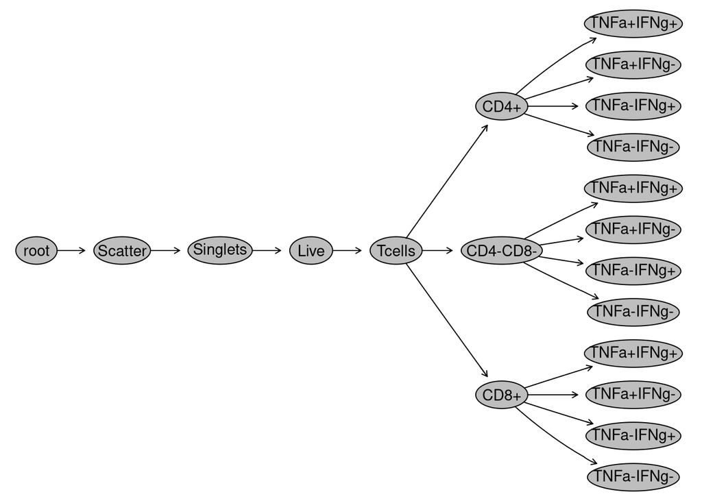

```r
plot(gs)
```

```r
gs_get_pop_paths(gs)
```

```
 [1] "root"
 [2] "/Scatter"
 [3] "/Scatter/Singlets"
 [4] "/Scatter/Singlets/Live"
 [5] "/Scatter/Singlets/Live/Tcells"
 [6] "/Scatter/Singlets/Live/Tcells/CD4+"
 [7] "/Scatter/Singlets/Live/Tcells/CD4+/TNFa+IFNg+"
 [8] "/Scatter/Singlets/Live/Tcells/CD4+/TNFa+IFNg-"
 [9] "/Scatter/Singlets/Live/Tcells/CD4+/TNFa-IFNg+"
[10] "/Scatter/Singlets/Live/Tcells/CD4+/TNFa-IFNg-"
[11] "/Scatter/Singlets/Live/Tcells/CD4-CD8-"
[12] "/Scatter/Singlets/Live/Tcells/CD4-CD8-/TNFa+IFNg+"
[13] "/Scatter/Singlets/Live/Tcells/CD4-CD8-/TNFa+IFNg-"
[14] "/Scatter/Singlets/Live/Tcells/CD4-CD8-/TNFa-IFNg+"
[15] "/Scatter/Singlets/Live/Tcells/CD4-CD8-/TNFa-IFNg-"
[16] "/Scatter/Singlets/Live/Tcells/CD8+"
[17] "/Scatter/Singlets/Live/Tcells/CD8+/TNFa+IFNg+"
[18] "/Scatter/Singlets/Live/Tcells/CD8+/TNFa+IFNg-"
[19] "/Scatter/Singlets/Live/Tcells/CD8+/TNFa-IFNg+"
[20] "/Scatter/Singlets/Live/Tcells/CD8+/TNFa-IFNg-"
```

```r
data <- flowWorkspace::gs_pop_get_count_fast(gs)
head(data, 5)
```

| name | Population | Parent | Count | ParentCount |
| --- | --- | --- | --- | --- |
| 00_Ctrl.fcs_INF052 | /Scatter | root | 10000 | 10000 |
| 00_Ctrl.fcs_INF052 | /Scatter/Singlets | /Scatter | 9986 | 10000 |
| 00_Ctrl.fcs_INF052 | /Scatter/Singlets/Live | /Scatter/Singlets | 9708 | 9986 |
| 00_Ctrl.fcs_INF052 | /Scatter/Singlets/Live/Tcells | /Scatter/Singlets/Live | 9708 | 9708 |
| 00_Ctrl.fcs_INF052 | /Scatter/Singlets/Live/Tcells/CD4+ | /Scatter/Singlets/Live/Tcells | 6151 | 9708 |

```r
data <- data %>%
    mutate(percent_of_parent = Count / ParentCount * 100)
```

I’m not sure if I understood the problem correctly.

```r
head(data, 5)
```

| name | Population | Parent | Count | ParentCount | percent_of_parent |
| --- | --- | --- | --- | --- | --- |
| 00_Ctrl.fcs_INF052 | /Scatter | root | 10000 | 10000 | 100.00000 |
| 00_Ctrl.fcs_INF052 | /Scatter/Singlets | /Scatter | 9986 | 10000 | 99.86000 |
| 00_Ctrl.fcs_INF052 | /Scatter/Singlets/Live | /Scatter/Singlets | 9708 | 9986 | 97.21610 |
| 00_Ctrl.fcs_INF052 | /Scatter/Singlets/Live/Tcells | /Scatter/Singlets/Live | 9708 | 9708 | 100.00000 |
| 00_Ctrl.fcs_INF052 | /Scatter/Singlets/Live/Tcells/CD4+ | /Scatter/Singlets/Live/Tcells | 6151 | 9708 | 63.36012 |

## Problem 2

> As we saw, CytoML can be finicky when names are repeated, or .fcs files are not present. Try removing a couple of the .fcs files from the data folder, and re-run the code. Document what kind of errors result.

```r
my_move <- function(files, to) {
    #file.rename(files, to)  # This does not work since files and to should be vectors of equal length
    files %>% map(~ file.rename(., file.path(to, basename(.))))
}
tmp_dir <- file.path("tmp")
if (! dir.exists(tmp_dir)) dir.create(tmp_dir)
couple_files <- fcs_files[c(1,4, 5)]
#my_move(couple_files, tmp_dir)
fs::file_move(couple_files, tmp_dir)   # This is easiest
#file.copy(couple_files, tmp_dir)
#file.remove(couple_files)
```

```r
list.files(data_path)
```

```
[1] "2025_07_26_AB_02_INF052_00_SEB.fcs"  "2025_07_26_AB_02_INF100_00_Ctrl.fcs"
[3] "2025_07_26_AB_02_INF179_00_SEB.fcs"  "FloreadaWorkspace.xml"
[5] "FlowJoWSP_OpenedCopy.wsp"            "FlowJoWSP_Unopened.wsp"
[7] "tmp"
```

```r
gs <- CytoML::flowjo_to_gatingset(ws=ws, name=1, path = data_path, additional.keys="GROUPNAME")
```

```
FCS not found for sample 00_SEB.fcs_INF100 from searching the file extension: .fcs
```

```r
gs
```

```
A GatingSet with 5 samples
```

I got the following message:

```
FCS not found for sample 00_SEB.fcs_INF100 from searching the file extension: .fcs
A GatingSet with 5 samples
```

Why the result contained 5 samples instead of 3, as I moved 3 files away?

```r
pData(gs)
```

|  | name |
| --- | --- |
| 00_Ctrl.fcs_INF052 | 00_Ctrl.fcs |
| 00_Ctrl.fcs_INF100 | 00_Ctrl.fcs |
| 00_Ctrl.fcs_INF179 | 00_Ctrl.fcs |
| 00_SEB.fcs_INF052 | 00_SEB.fcs |
| 00_SEB.fcs_INF179 | 00_SEB.fcs |

Move files to a nested subdirectory.

```r
nested_tmp_dir <- file.path(data_path, "tmp")
if (! dir.exists(nested_tmp_dir)) dir.create(nested_tmp_dir)
tmp_files <- list.files(tmp_dir, pattern="*.fcs", full.names = TRUE)
fs::file_move(tmp_files, nested_tmp_dir)
```

```r
gs <- CytoML::flowjo_to_gatingset(ws=ws, name=1, path = data_path,
    additional.keys="GROUPNAME")
gs
```

```
A GatingSet with 6 samples
```

```r
pData(gs)
```

|  | name |
| --- | --- |
| 00_Ctrl.fcs_INF052 | 00_Ctrl.fcs |
| 00_Ctrl.fcs_INF100 | 00_Ctrl.fcs |
| 00_Ctrl.fcs_INF179 | 00_Ctrl.fcs |
| 00_SEB.fcs_INF052 | 00_SEB.fcs |
| 00_SEB.fcs_INF100 | 00_SEB.fcs |
| 00_SEB.fcs_INF179 | 00_SEB.fcs |

From there it found all files, recursively.

Move the file back to original location.

```r
tmp_files <- list.files(nested_tmp_dir, pattern="*.fcs", full.names = TRUE)
fs::file_move(tmp_files, data_path)
```

If I move all SEB files away, I get the following message:

```r
couple_files <- fcs_files %>% keep(~ str_detect(., "SEB"))
```

[output not shown]

So, maybe CytoML::flowjo_to_gatingset creates automatically some control file?

## Problem 3

> For ggcyto, attempt to generate plots to visualize TNFa and IFNg for the various cell populations, across both Ctrl and SEB samples. In the process, change the bins argument until you end up with a resolution that you would be happy with for your own plots, and write it down.

### CD8+

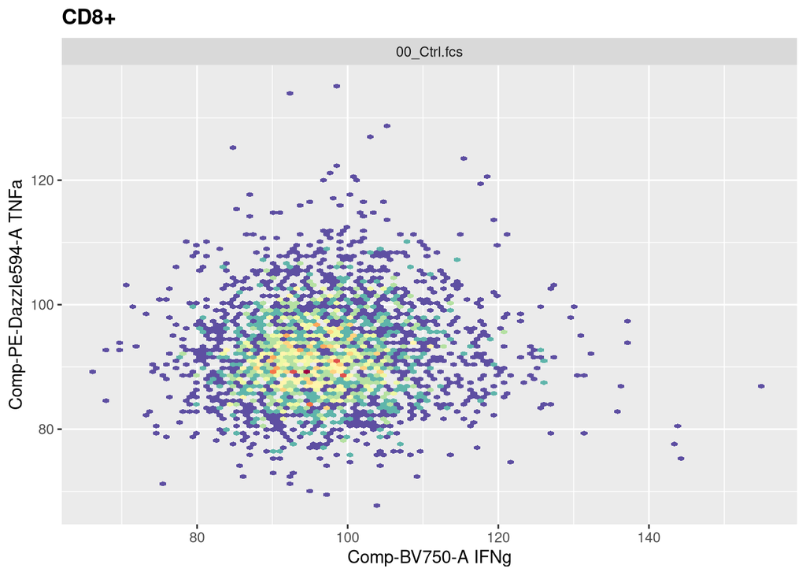

```r
g1 <- ggcyto(gs[1], subset="CD8+", aes(x="IFNg", y="TNFa")) + geom_hex(bins=100)
g1
```

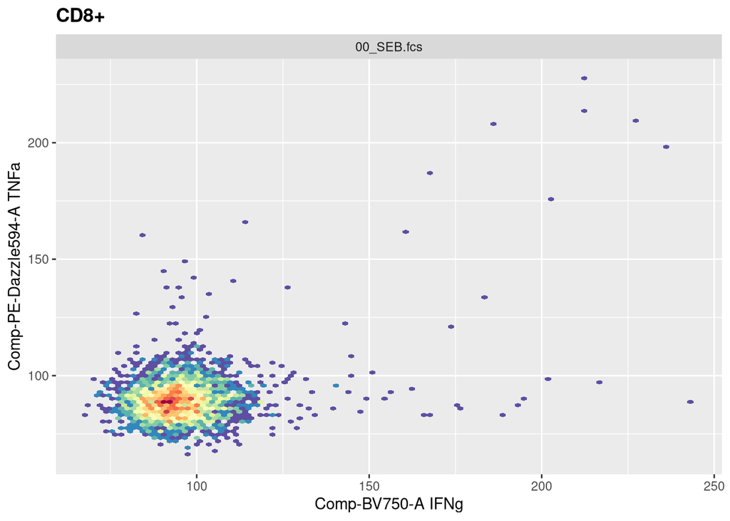

```r
g2 <- ggcyto(gs[4], subset="CD8+", aes(x="IFNg", y="TNFa")) + geom_hex(bins=100)
g2
```

### CD4+

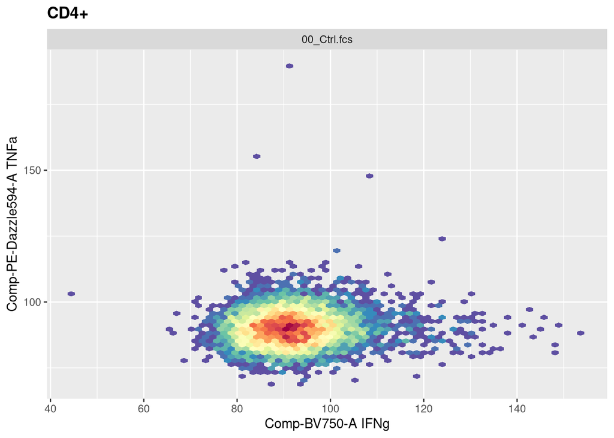

```r
g1 <- ggcyto(gs[1], subset="CD4+", aes(x="IFNg", y="TNFa")) + geom_hex(bins=70)
g1
```

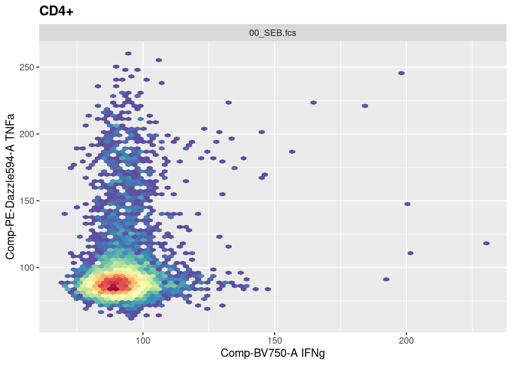

```r
g2 <- ggcyto(gs[4], subset="CD4+", aes(x="IFNg", y="TNFa")) + geom_hex(bins=70)
g2
```